# Capstone Project- Lending Club

### Introduction

- In the last few years, applying for different types of loans through online peer-to-peer lending platforms such as the LendingClub is raising. What is the LendingClub?
- "LendingClub is a US peer-to-peer lending company, headquartered in San Francisco, California. It was the first peer-to-peer lender to register its offerings as securities with the Securities and Exchange Commission (SEC), and to offer loan trading on a secondary market. LendingClub is the world's largest peer-to-peer lending platform." Wikipedia-Lending club
- On the LendingClub platform, people invest on other people loan through an online secured system. On these types of platforms, in the most cases, the main criteria of giving loans to costumers is solely based on their credit scores, so that a customer with lower credit score (more risky) get higher rate and customer with higher credit score (less risky) get lower interest rate for their loan. Obviously, from the investor point of view, the loans with higher interest rate are more attractive due to their higher return of investment. However, it also has high risk of being not returned at all.
- So, investing on "Bad loans" or charged-off, which means you loose your asset, is more worse than loosing an opportunity to gain more profit.
- The machine learning/deep learning model that could predict which of the high interest loans are more likely to be returned, would bring added value by minimizing the associated risks. Also, using other factors along with credit score may help us to identify the high risky loans and minimize the investors loss of money more accurately.

### Our Goal

In this capstone project, You will going to work on LendingClub Dataset obtained from Kaggle and the goal is to try find a better prediction model to prevent investing on '"bad loans".

This way in the future when we get a new potential customer who assigned with higher interest loan, we can assess whether or not they are likely to pay back the loan.

### LoanStatNew Description

- addr_state: The state provided by the borrower in the loan application
- annual_inc: The self-reported annual income provided by the borrower during registration.
- annual_inc_joint: The combined self-reported annual income provided by the co-borrowers during registration
- application_type: Indicates whether the loan is an individual application or a joint application with two co-borrowers
- collection_recovery_fee: post charge off collection fee
- collections_12_mths_ex_med: Number of collections in 12 months excluding medical collections
- delinq_2yrs: The number of 30+ days past-due incidences of delinquency in the borrower's credit file for the past 2 years
- desc: Loan description provided by the borrower
- dti: A ratio calculated using the borrower’s total monthly debt payments on the total debt obligations, excluding mortgage and the requested LC loan, divided by the borrower’s self-reported monthly income.
- dti_joint: A ratio calculated using the co-borrowers' total monthly payments on the total debt obligations, excluding mortgages and the requested LC loan, divided by the co-borrowers' combined self-reported monthly income.
- earliest_cr_line: The month the borrower's earliest reported credit line was opened.
- emp_length: Employment length in year, Possible values are between 0 and 10 where 0 means less than one year and 10 means ten or more years.
- emp_title: The job title supplied by the Borrower when applying for the loan.*
- fico_range_high: The upper boundary range the borrower’s FICO at loan origination belongs to.
- fico_range_low: The lower boundary range the borrower’s FICO at loan origination belongs to.
- funded_amnt: The total amount committed to that loan at that point in time.
- funded_amnt_inv: The total amount committed by investors for that loan at that point in time.
- grade: LC assigned loan grade
- home_ownership: The home ownership status provided by the borrower during registration. Our values are: RENT, OWN, MORTGAGE, OTHER.
- id: A unique LC assigned ID for the loan listing.
- initial_list_status: The initial listing status of the loan. Possible values are – W, F
- inq_last_6mths: The number of inquiries in past 6 months (excluding auto and mortgage inquiries)
- installment: The monthly payment owed by the borrower if the loan originates.
- int_rate: Interest Rate on the loan
- is_inc_v: Indicates if income was verified by LC, not verified, or if the income source was verified
- issue_d: The month which the loan was funded
- last_credit_pull_d: The most recent month LC pulled credit for this loan
- last_fico_range_high: The upper boundary range the borrower’s last FICO pulled belongs to.
- last_fico_range_low: The lower boundary range the borrower’s last FICO pulled belongs to.
- last_pymnt_amnt: Last total payment amount received
- last_pymnt_d: Last month payment was received
- loan_amnt: The listed amount of the loan applied for by the borrower. If at some point in time, the credit department reduces the loan amount, then it will be reflected in this value.
- loan_status: Current status of the loan
- member_id: A unique LC assigned Id for the borrower member.
- mths_since_last_delinq: The number of months since the borrower's last delinquency.
- mths_since_last_major_derog: Months since most recent 90-day or worse rating
- mths_since_last_record: The number of months since the last public record.
- next_pymnt_d: Next scheduled payment date
- open_acc: The number of open credit lines in the borrower's credit file.
- out_prncp: Remaining outstanding principal for total amount funded
- out_prncp_inv: Remaining outstanding principal for portion of total amount funded by investors
- policy_code: publicly available policy_code=1 new products not publicly available policy_code=2
- pub_rec: Number of derogatory public records
- purpose: A category provided by the borrower for the loan request.
- pymnt_plan: Indicates if a payment plan has been put in place for the loan
- recoveries: post charge off gross recovery
- revol_bal: Total credit revolving balance
- revol_util: Revolving line utilization rate, or the amount of credit the borrower is using relative to all available revolving credit.
- sub_grade: LC assigned loan subgrade
- term: The number of payments on the loan. Values are in months and can be either 36 or 60.
- title: The loan title provided by the borrower
- total_acc: The total number of credit lines currently in the borrower's credit file
- total_pymnt: Payments received to date for total amount funded
- total_pymnt_inv: Payments received to date for portion of total amount funded by investors
- total_rec_int: Interest received to date
- total_rec_late_fee: Late fees received to date
- total_rec_prncp: Principal received to date
- url: URL for the LC page with listing data.
- verified_status_joint: Indicates if the co-borrowers' joint income was verified by LC, not verified, or if the income source was verified.
- zip_code: The first 3 numbers of the zip code provided by the borrower in the loan application.
- open_acc_6m: Number of open trades in last 6 months
- open_il_6m: Number of currently active installment trades
- open_il_12m: Number of installment accounts opened in past 12 months
- open_il_24m: Number of installment accounts opened in past 24 months
- mths_since_rcnt_il: Months since most recent installment accounts opened
- total_bal_il: Total current balance of all installment accounts
- il_util: Ratio of total current balance to high credit/credit limit on all install acct
- open_rv_12m: Number of revolving trades opened in past 12 months
- open_rv_24m: Number of revolving trades opened in past 24 months
- max_bal_bc: Maximum current balance owed on all revolving accounts
- all_util: Balance to credit limit on all trades
- total_rev_hi_lim: Total revolving high credit/credit limit
- inq_fi: Number of personal finance inquiries
- total_cu_tl: Number of finance trades
- inq_last_12m: Number of credit inquiries in past 12 months
- acc_now_delinq: The number of accounts on which the borrower is now delinquent.
- tot_coll_amt: Total collection amounts ever owed
- tot_cur_bal: Total current balance of all accounts

## Importing LIbraries and Understanding Data

```python
import numpy as np
import pandas as pd
import matplotlib.pyplot as plt
import seaborn as sns
%matplotlib inline

import warnings
warnings.filterwarnings("ignore")
```

## Read the Data

```python
data = pd.read_csv('accepted_2007_to_2018Q4.csv')
```

```python
data.head()
```

|  | id | member_id | loan_amnt | funded_amnt | funded_amnt_inv | term | int_rate | installment | grade | sub_grade | ... | total_bal_il | il_util | open_rv_12m | open_rv_24m | max_bal_bc | all_util | total_rev_hi_lim | inq_fi | total_cu_tl | inq_last_12m |
| --- | --- | --- | --- | --- | --- | --- | --- | --- | --- | --- | --- | --- | --- | --- | --- | --- | --- | --- | --- | --- | --- |
| 0 | 68407277 | NaN | 3600.0 | 3600.0 | 3600.0 | 36 months | 13.99 | 123.03 | C | C4 | ... | 4981.0 | 36.0 | 3.0 | 3.0 | 722.0 | 34.0 | 9300.0 | 3.0 | 1.0 | 4.0 |
| 1 | 68355089 | NaN | 24700.0 | 24700.0 | 24700.0 | 36 months | 11.99 | 820.28 | C | C1 | ... | 18005.0 | 73.0 | 2.0 | 3.0 | 6472.0 | 29.0 | 111800.0 | 0.0 | 0.0 | 6.0 |
| 2 | 68341763 | NaN | 20000.0 | 20000.0 | 20000.0 | 60 months | 10.78 | 432.66 | B | B4 | ... | 10827.0 | 73.0 | 0.0 | 2.0 | 2081.0 | 65.0 | 14000.0 | 2.0 | 5.0 | 1.0 |
| 3 | 66310712 | NaN | 35000.0 | 35000.0 | 35000.0 | 60 months | 14.85 | 829.90 | C | C5 | ... | 12609.0 | 70.0 | 1.0 | 1.0 | 6987.0 | 45.0 | 67300.0 | 0.0 | 1.0 | 0.0 |
| 4 | 68476807 | NaN | 10400.0 | 10400.0 | 10400.0 | 60 months | 22.45 | 289.91 | F | F1 | ... | 73839.0 | 84.0 | 4.0 | 7.0 | 9702.0 | 78.0 | 34000.0 | 2.0 | 1.0 | 3.0 |

5 rows × 78 columns

```python
data.shape
```

```
(1048575, 78)
```

## Lets check the data type

```python
data.dtypes
```

```
id                   object
member_id           float64
loan_amnt           float64
funded_amnt         float64
funded_amnt_inv     float64
                     ...
all_util            float64
total_rev_hi_lim    float64
inq_fi              float64
total_cu_tl         float64
inq_last_12m        float64
Length: 78, dtype: object
```

## Let's check the summary of data

```python
data.info()
```

```
<class 'pandas.core.frame.DataFrame'>
RangeIndex: 1048575 entries, 0 to 1048574
Data columns (total 78 columns):
 #   Column                       Non-Null Count    Dtype
---  ------                       --------------    -----
 0   id                           1048575 non-null  object
 1   member_id                    0 non-null        float64
 2   loan_amnt                    1048563 non-null  float64
 3   funded_amnt                  1048563 non-null  float64
 4   funded_amnt_inv              1048563 non-null  float64
 5   term                         1048563 non-null  object
 6   int_rate                     1048563 non-null  float64
 7   installment                  1048563 non-null  float64
 8   grade                        1048563 non-null  object
 9   sub_grade                    1048563 non-null  object
```

[output cut: 70 more lines]

```python
data.describe()
```

|  | member_id | loan_amnt | funded_amnt | funded_amnt_inv | int_rate | installment | annual_inc | dti | delinq_2yrs | fico_range_low | ... | total_bal_il | il_util | open_rv_12m | open_rv_24m | max_bal_bc | all_util | total_rev_hi_lim | inq_fi | total_cu_tl | inq_last_12m |
| --- | --- | --- | --- | --- | --- | --- | --- | --- | --- | --- | --- | --- | --- | --- | --- | --- | --- | --- | --- | --- | --- |
| count | 0.0 | 1.048563e+06 | 1.048563e+06 | 1.048563e+06 | 1.048563e+06 | 1.048563e+06 | 1.048563e+06 | 1.047707e+06 | 1.048563e+06 | 1.048563e+06 | ... | 6.488400e+05 | 555126.000000 | 648840.000000 | 648840.000000 | 648840.000000 | 648748.000000 | 1.048563e+06 | 648840.00000 | 648840.000000 | 648840.000000 |
| mean | NaN | 1.525010e+04 | 1.525008e+04 | 1.524465e+04 | 1.277206e+01 | 4.477775e+02 | 7.826763e+04 | 1.932878e+01 | 3.225748e-01 | 6.981973e+02 | ... | 3.544193e+04 | 69.062854 | 1.289489 | 2.758520 | 5814.970760 | 57.096110 | 3.513892e+04 | 1.00553 | 1.478178 | 2.037627 |
| std | NaN | 9.227339e+03 | 9.227341e+03 | 9.225066e+03 | 4.853020e+00 | 2.669758e+02 | 1.309236e+05 | 1.483836e+01 | 9.016415e-01 | 3.306642e+01 | ... | 4.382664e+04 | 23.908112 | 1.502850 | 2.599039 | 5635.486927 | 20.941737 | 3.661790e+04 | 1.47923 | 2.668746 | 2.380570 |
| min | NaN | 1.000000e+03 | 1.000000e+03 | 7.500000e+02 | 5.310000e+00 | 1.401000e+01 | 0.000000e+00 | -1.000000e+00 | 0.000000e+00 | 6.600000e+02 | ... | 0.000000e+00 | 0.000000 | 0.000000 | 0.000000 | 0.000000 | 0.000000 | 0.000000e+00 | 0.00000 | 0.000000 | 0.000000 |
| 25% | NaN | 8.000000e+03 | 8.000000e+03 | 8.000000e+03 | 9.170000e+00 | 2.541700e+02 | 4.600000e+04 | 1.220000e+01 | 0.000000e+00 | 6.700000e+02 | ... | 8.722000e+03 | 55.000000 | 0.000000 | 1.000000 | 2284.000000 | 43.000000 | 1.480000e+04 | 0.00000 | 0.000000 | 0.000000 |
| 50% | NaN | 1.320000e+04 | 1.320000e+04 | 1.320000e+04 | 1.229000e+01 | 3.797600e+02 | 6.500000e+04 | 1.827000e+01 | 0.000000e+00 | 6.900000e+02 | ... | 2.312600e+04 | 72.000000 | 1.000000 | 2.000000 | 4416.000000 | 58.000000 | 2.580000e+04 | 0.00000 | 0.000000 | 1.000000 |
| 75% | NaN | 2.000000e+04 | 2.000000e+04 | 2.000000e+04 | 1.559000e+01 | 5.955250e+02 | 9.400000e+04 | 2.515000e+01 | 0.000000e+00 | 7.150000e+02 | ... | 4.607700e+04 | 86.000000 | 2.000000 | 4.000000 | 7619.000000 | 72.000000 | 4.390000e+04 | 1.00000 | 2.000000 | 3.000000 |
| max | NaN | 4.000000e+04 | 4.000000e+04 | 4.000000e+04 | 3.099000e+01 | 1.719830e+03 | 1.100000e+08 | 9.990000e+02 | 5.800000e+01 | 8.450000e+02 | ... | 1.711009e+06 | 1000.000000 | 26.000000 | 53.000000 | 776843.000000 | 239.000000 | 9.999999e+06 | 38.00000 | 111.000000 | 49.000000 |

8 rows × 54 columns

## Total Unique Value

```python
data.nunique()
```

```
id                  1048575
member_id                 0
loan_amnt              1561
funded_amnt            1561
funded_amnt_inv        1575
                     ...
all_util                175
total_rev_hi_lim      18511
inq_fi                   29
total_cu_tl              55
inq_last_12m             44
Length: 78, dtype: int64
```

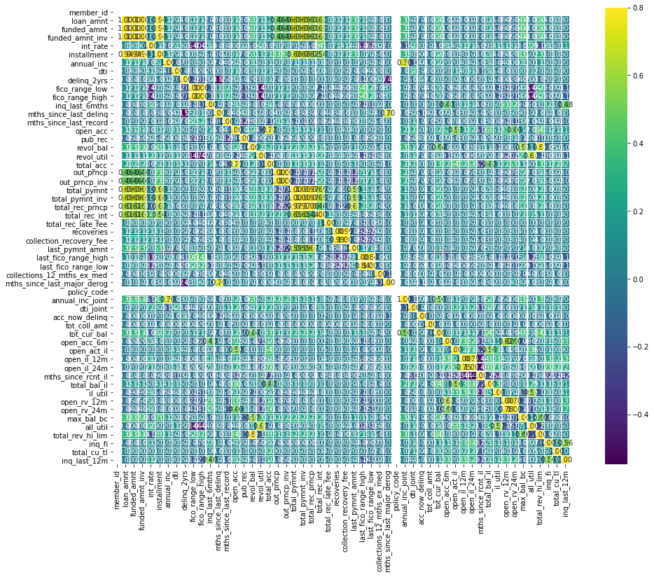

```python
colormap = plt.cm.viridis
cor = data.corr()
plt.figure(figsize=(18,12))
sns.heatmap(cor,vmax=0.8,cmap=colormap,annot=True,fmt='.2f',square=True,annot_kws={'size':10},linecolor='white',linewidths=0.1)
```

## Total Missing Values

```python
# Total missing values in every column
total_missing = data.isnull().sum()

# Calculate percentage
percentge = total_missing/data.isnull().count()

# Combine total and percentage values
NAs = pd.concat([total_missing,percentge],axis=1,keys=('Total','Percentge'))

# Getting columns where there are missing values
NAs[NAs.Total>0].sort_values(by='Total',ascending=False)
```

|  | Total | Percentge |
| --- | --- | --- |
| member_id | 1048575 | 1.000000 |
| desc | 1048518 | 0.999946 |
| verification_status_joint | 992619 | 0.946636 |
| dti_joint | 990252 | 0.944379 |
| annual_inc_joint | 990249 | 0.944376 |
| ... | ... | ... |
| total_rec_late_fee | 12 | 0.000011 |
| recoveries | 12 | 0.000011 |
| collection_recovery_fee | 12 | 0.000011 |
| last_pymnt_amnt | 12 | 0.000011 |
| out_prncp_inv | 12 | 0.000011 |

77 rows × 2 columns

- The percentage of missing data in many columns are far more than we can work with.
- So, we'll have to remove columns having a certain percentage of data less than the total data later on.

## Data Visualization

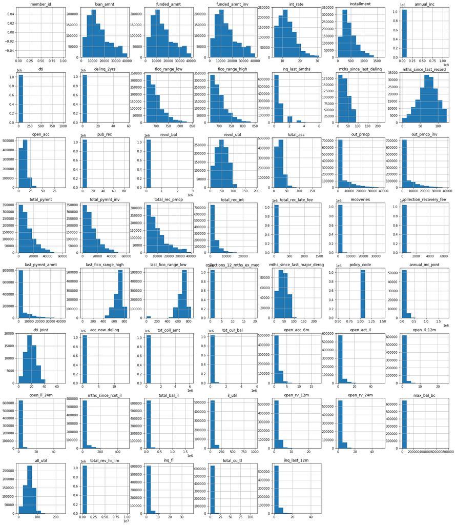

```python
data.hist(figsize=(25,30))
plt.show()
```

- We can observe that more number of people are requested for 5000,10000,150000,20000,35000
- we can observe most of the loans with intrest rate ranging b/w 7.5% to 17.5%
- We can see that many of barrowers dont have any installment account opened in past 12 months, some have 1 or 2 accounts.

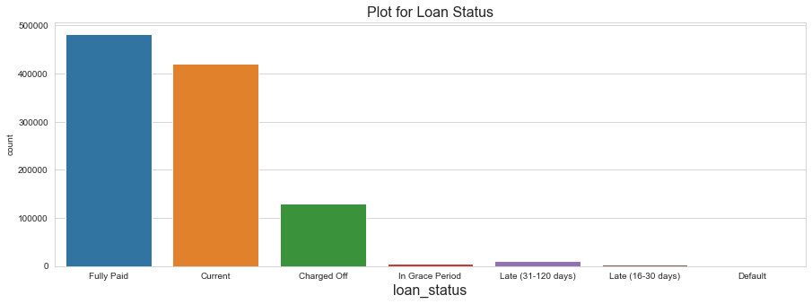

```python
sns.set_style("whitegrid")
plt.figure(figsize=(15,5))
sns.countplot('loan_status', data = data)
plt.xlabel('loan_status', fontsize = 16)
plt.title('Plot for Loan Status', fontsize = 16)
```

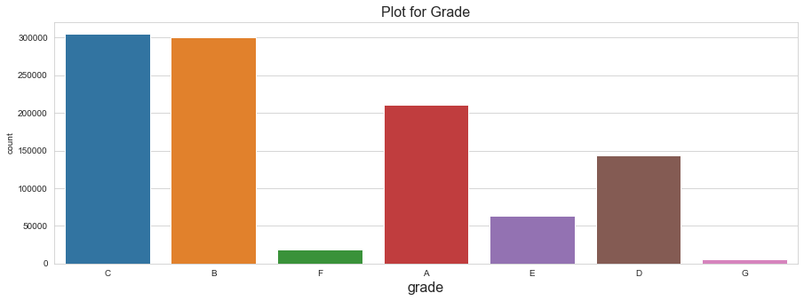

```python
sns.set_style("whitegrid")
plt.figure(figsize=(15,5))
sns.countplot('grade', data = data)
plt.xlabel('grade', fontsize = 16)
plt.title('Plot for Grade', fontsize = 16)
```

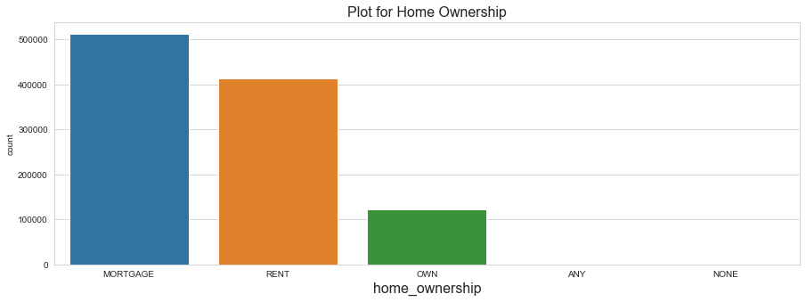

```python
sns.set_style("whitegrid")
plt.figure(figsize=(15,5))
sns.countplot('home_ownership', data = data)
plt.xlabel('home_ownership', fontsize = 16)
plt.title('Plot for Home Ownership', fontsize = 16)
```

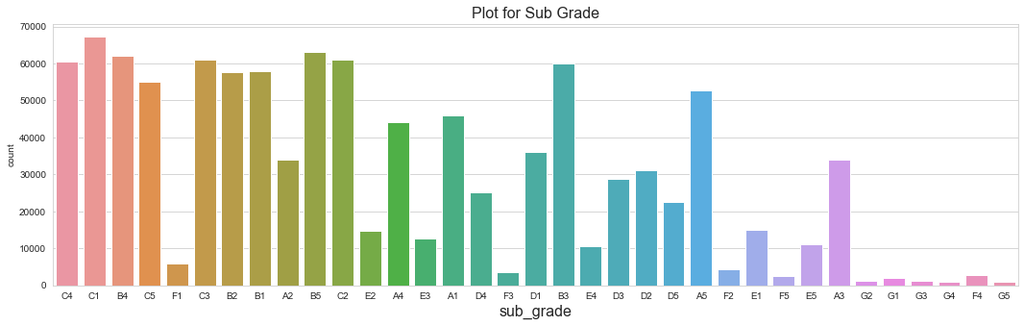

```python
sns.set_style("whitegrid")
plt.figure(figsize=(18,5))
sns.countplot('sub_grade', data = data)
plt.xlabel('sub_grade', fontsize = 16)
plt.title('Plot for Sub Grade', fontsize = 16)
```

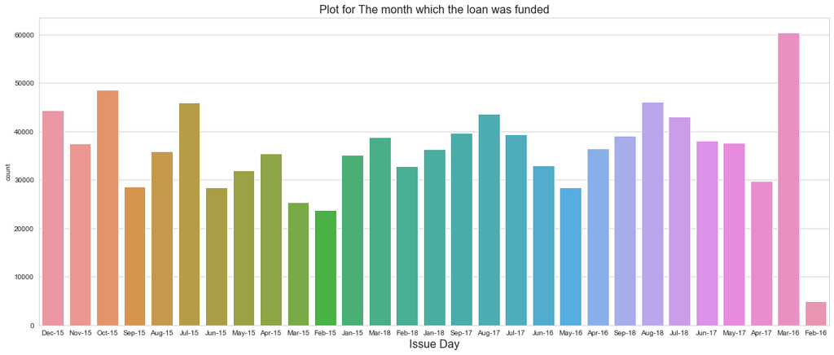

```python
sns.set_style("whitegrid")
plt.figure(figsize=(20,8))
sns.countplot('issue_d', data = data)
plt.xlabel('Issue Day', fontsize = 16)
plt.title('Plot for The month which the loan was funded', fontsize = 16)
```

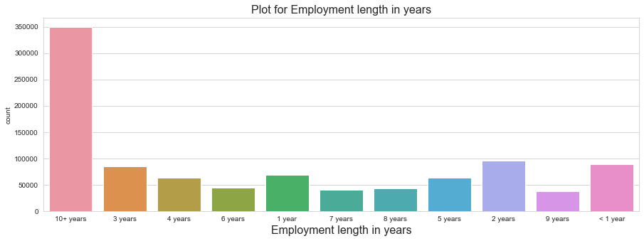

```python
sns.set_style("whitegrid")
plt.figure(figsize=(15,5))
sns.countplot('emp_length', data = data)
plt.xlabel('Employment length in years', fontsize = 16)
plt.title('Plot for Employment length in years', fontsize = 16)
```

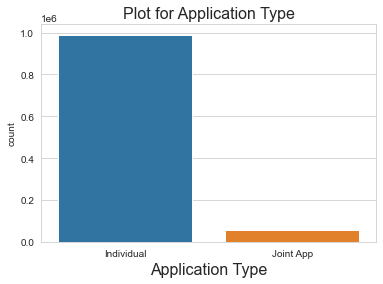

```python
sns.set_style("whitegrid")
sns.countplot('application_type', data = data)
plt.xlabel('Application Type', fontsize = 16)
plt.title('Plot for Application Type', fontsize = 16)
```

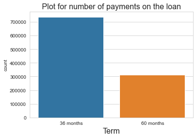

```python
sns.set_style("whitegrid")
sns.countplot('term', data = data)
plt.xlabel('Term', fontsize = 16)
plt.title('Plot for number of payments on the loan', fontsize = 16)
```

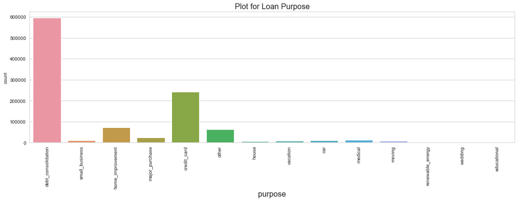

```python
sns.set_style("whitegrid")
plt.figure(figsize=(18,5))
sns.countplot('purpose', data = data)
plt.xlabel('purpose', fontsize = 16)
plt.xticks(rotation='vertical')
plt.title('Plot for Loan Purpose', fontsize = 16)
```

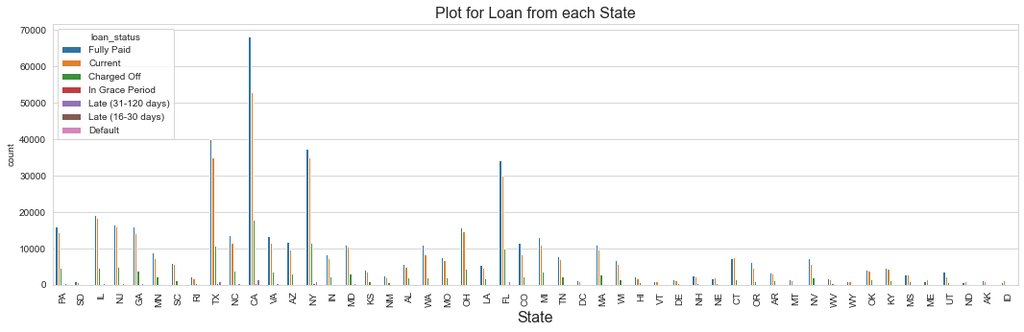

```python
sns.set_style("whitegrid")
plt.figure(figsize=(18,5))
sns.countplot(x = 'addr_state', hue = 'loan_status', data = data)
plt.xlabel('State', fontsize = 16)
plt.xticks(rotation='vertical')
plt.title('Plot for Loan from each State', fontsize = 16)
```

- Another thing we would want to examine is that how many loans have a default loan status in comparison to other loans.
- A common thing to predict in datasets like these are if a new loan will get default or not.
- I'll be keeping loans with default status as my target variable.

```python
target_list = [1 if i=='Default' else 0 for i in data['loan_status']]

data['TARGET'] = target_list
data['TARGET'].value_counts()
```

```
0    1048554
1         21
Name: TARGET, dtype: int64
```

```python
data.drop('loan_status', axis=1, inplace=True)
```

```python
data.select_dtypes('object').apply(pd.Series.nunique, axis = 0)
```

```
id                           1048575
term                               2
grade                              7
sub_grade                         35
emp_title                     237270
emp_length                        11
home_ownership                     5
verification_status                3
issue_d                           29
pymnt_plan                         2
url                          1048563
desc                              44
purpose                           14
title                             27
zip_code                         932
addr_state                        50
earliest_cr_line                 725
initial_list_status                2
last_pymnt_d                      51
next_pymnt_d                       7
last_credit_pull_d                53
application_type                   2
verification_status_joint          3
dtype: int64
```

- We would want to label encode the columns having only 2 categorical data and one-hot encode columns with more than 2 categorical data.
- Also, columns like emp_title, url, desc, etc.
- should be dropped because there aren't any large number of unique data for any of the categories they contain.
- Also, Principal Component Analysis can be carried out for the one-hot encoded columns to bring the feature dimensions down.

```python
data['emp_length'].head()
```

```
0    10+ years
1    10+ years
2    10+ years
3    10+ years
4      3 years
Name: emp_length, dtype: object
```

- I'll be filling the null values with 0 assuming that the borrower hasn't worked many years for his data to be recorded.
- Also, I'll be using regex to extract the number of years from all of the data.

```python
data['emp_length'].fillna(value=0, inplace=True)

data['emp_length'].replace(to_replace='[^0-9]+', value='', inplace=True, regex=True)
```

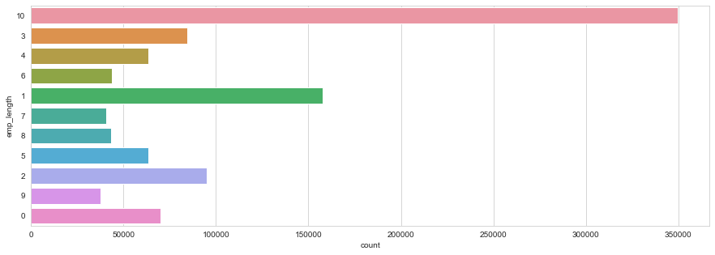

```python
plt.figure(figsize=(15,5))
sns.countplot(y = 'emp_length', data = data)
```

- It can be seen that people who have worked for 10 or more years are more likely to take a loan.

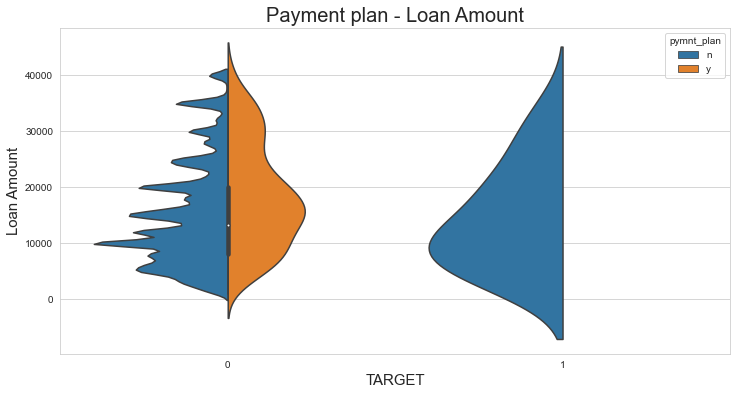

```python
fig = plt.figure(figsize=(12,6))
sns.violinplot(x = "TARGET", y = "loan_amnt", data = data, hue = "pymnt_plan", split = True)
plt.title("Payment plan - Loan Amount", fontsize=20)
plt.xlabel("TARGET", fontsize=15)
plt.ylabel("Loan Amount", fontsize=15);
```

- Naturally, the defaulted loans had no payment plan.

## Exploratory Data Analysis

```python
temp = [i for i in data.count()<887379 *0.30]
data.drop(data.columns[temp],axis=1,inplace=True)
```

```python
corr = data.corr()['TARGET'].sort_values()
```

```python
print('Most Positive Correlations:\n', corr.tail(10))
print('\nMost Negative Correlations:\n', corr.head(10))
```

```
Most Positive Correlations:
 fico_range_high       0.000985
fico_range_low        0.000985
total_rec_int         0.002665
open_rv_24m           0.002866
out_prncp             0.003462
out_prncp_inv         0.003463
int_rate              0.004191
total_rec_late_fee    0.011698
TARGET                1.000000
policy_code                NaN
Name: TARGET, dtype: float64

Most Negative Correlations:
 last_fico_range_high   -0.005849
last_fico_range_low    -0.003453
total_rec_prncp        -0.002698
last_pymnt_amnt        -0.002004
total_bal_il           -0.001720
inq_fi                 -0.001710
total_pymnt            -0.001666
total_pymnt_inv        -0.001664
revol_bal              -0.001300
max_bal_bc             -0.001273
Name: TARGET, dtype: float64
```

```python
data.corr()['dti'].sort_values().tail(6)
```

```
open_act_il     0.135853
total_acc       0.144588
total_bal_il    0.148272
open_acc        0.178116
dti             1.000000
policy_code          NaN
Name: dti, dtype: float64
```

```python
data['open_act_il']
```

```
0          2.0
1          1.0
2          1.0
3          1.0
4          3.0
          ...
1048570    2.0
1048571    3.0
1048572    1.0
1048573    2.0
1048574    3.0
Name: open_act_il, Length: 1048575, dtype: float64
```

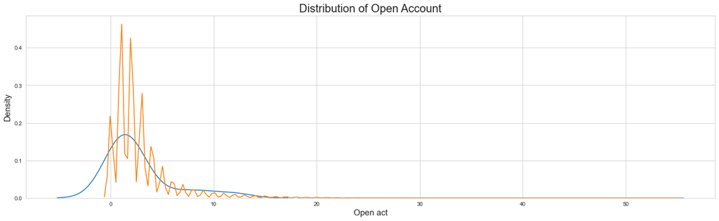

```python
fig = plt.figure(figsize=(22,6))
sns.kdeplot(data.loc[data['TARGET'] == 1, 'open_act_il'], label = 'target = 1')
sns.kdeplot(data.loc[data['TARGET'] == 0, 'open_act_il'], label = 'target = 0');
plt.xlabel('Open act',fontsize=15)
plt.ylabel('Density',fontsize=15)
plt.title('Distribution of Open Account',fontsize=20);
```

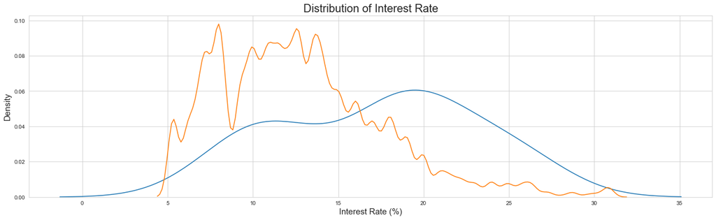

```python
fig = plt.figure(figsize=(22,6))
sns.kdeplot(data.loc[data['TARGET'] == 1, 'int_rate'], label = 'target = 1')
sns.kdeplot(data.loc[data['TARGET'] == 0, 'int_rate'], label = 'target = 0');
plt.xlabel('Interest Rate (%)',fontsize=15)
plt.ylabel('Density',fontsize=15)
plt.title('Distribution of Interest Rate',fontsize=20);
```

- The density of interest rates follow kind of a Gaussian distribution with more density on interest rates between 7.5% - 17.5%
- While we are looking at distributions, some other distributions that would be interesting to examine are

#### TARGET classes with distribution of loan amount differentiated by the terms.

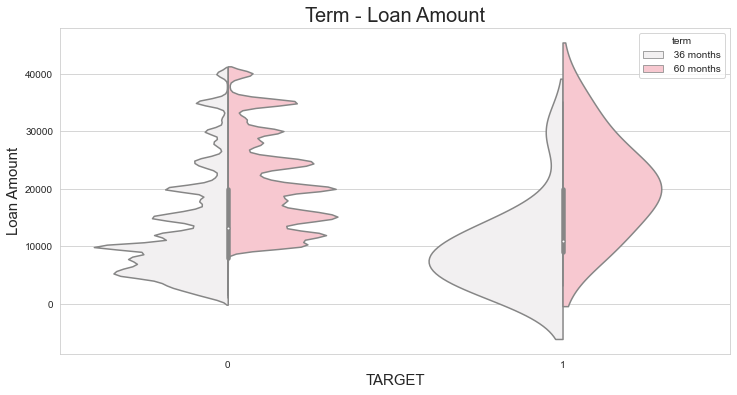

```python
fig = plt.figure(figsize=(12,6))
sns.violinplot(x = "TARGET", y = "loan_amnt", data = data, hue = "term", split = True, color = 'pink')
plt.title("Term - Loan Amount", fontsize=20)
plt.xlabel("TARGET", fontsize=15)
plt.ylabel("Loan Amount", fontsize=15);
```

- Most of the Loans of higher terms have high amount and vice versa for the TARGET classes

#### TARGET classes with distribution of loan amount differentiated by the application type.

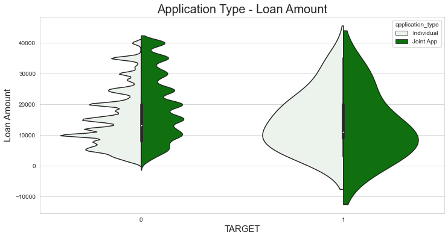

```python
fig = plt.figure(figsize=(12,6))
sns.violinplot(x = "TARGET", y = "loan_amnt", data = data, hue = "application_type", split = True, color = 'green')
plt.title("Application Type - Loan Amount", fontsize=20)
plt.xlabel("TARGET", fontsize=15)
plt.ylabel("Loan Amount", fontsize=15);
```

```python
data['application_type'].value_counts()
```

```
Individual    990237
Joint App      58326
Name: application_type, dtype: int64
```

- Seeing the number of joint applicants in comparison to the the total applicants, it isn't significant enough to conclude that the loan taken by all Joint applicants are paid back.

#### TARGET classes with distribution of interest rate differentiated by the loan grades.

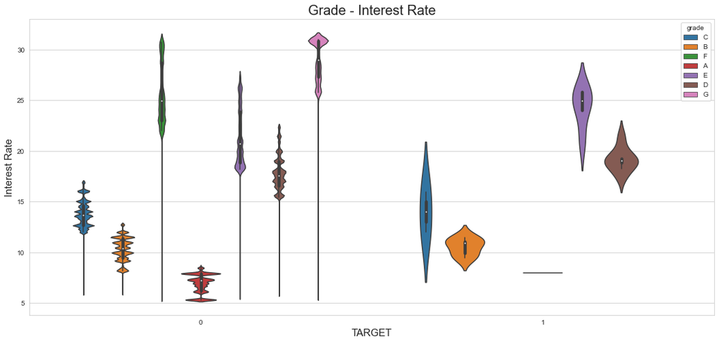

```python
fig = plt.figure(figsize=(18,8))
sns.violinplot(x = "TARGET", y = "int_rate", data = data, hue = "grade")
plt.title("Grade - Interest Rate", fontsize=20)
plt.xlabel("TARGET", fontsize=15)
plt.ylabel("Interest Rate", fontsize=15);
```

```python
data.corr()['annual_inc'].sort_values().tail(10)
```

```
max_bal_bc          0.134852
total_rev_hi_lim    0.163298
revol_bal           0.163549
installment         0.165952
loan_amnt           0.172918
funded_amnt         0.172918
funded_amnt_inv     0.172935
tot_cur_bal         0.219912
annual_inc          1.000000
policy_code              NaN
Name: annual_inc, dtype: float64
```

#### Most of the loans tend to be defaulted?

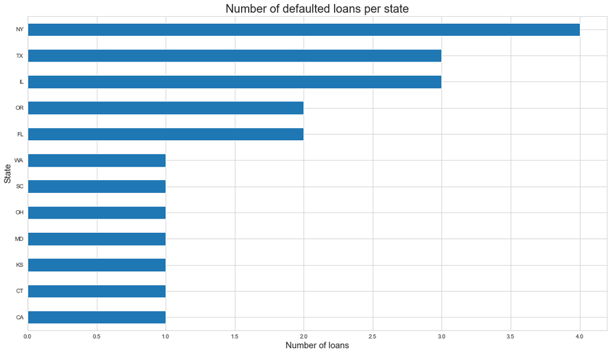

```python
fig = plt.figure(figsize=(18,10))
data[data['TARGET']==1].groupby('addr_state')['TARGET'].count().sort_values().plot(kind='barh')
plt.ylabel('State',fontsize=15)
plt.xlabel('Number of loans',fontsize=15)
plt.title('Number of defaulted loans per state',fontsize=20);
```

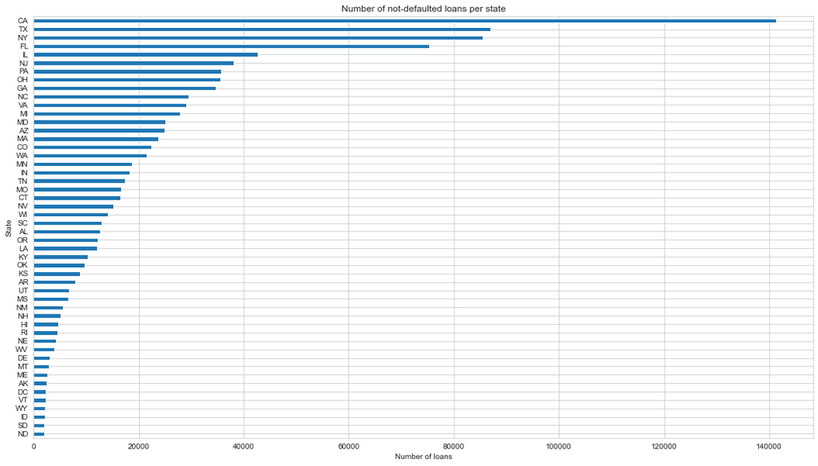

```python
fig = plt.figure(figsize=(18,10))
data[data['TARGET']==0].groupby('addr_state')['TARGET'].count().sort_values().plot(kind='barh')
plt.ylabel('State')
plt.xlabel('Number of loans')
plt.title('Number of not-defaulted loans per state');
```

- It can be seen that there are more number of loans taken amount from the same states where there are more number of defaulted risk. This is why the state cannot be taken as a major feature for knowing if a loan will be defaulted or not.

```python
data['emp_title'].value_counts().head()
```

```
Teacher             19859
Manager             17547
Owner               11416
Registered Nurse     7918
RN                   7523
Name: emp_title, dtype: int64
```

### Dropping the Unwanted Columns

```python
data.drop(['id','emp_title','title','zip_code','url'],axis=1,inplace=True)
```

## Handling Missing value

```python
data['issue_d'].fillna('Mar-16',inplace=True)
```

```python
data['last_pymnt_d'].fillna('Mar-19',inplace=True)
```

```python
data['last_credit_pull_d'].fillna('Mar-19',inplace=True)
```

```python
data.drop(columns=['mths_since_last_major_derog', 'next_pymnt_d','mths_since_last_delinq','il_util','mths_since_rcnt_il',
                  'all_util','inq_last_12m','open_acc_6m','open_il_12m','open_il_24m','total_cu_tl','open_rv_24m',
                   'open_rv_12m','open_act_il','inq_fi'], inplace = True)
```

```python
data['total_rev_hi_lim'].fillna(data['total_rev_hi_lim'].mean(),inplace=True)
```

```python
data['pub_rec'].fillna(data['pub_rec'].mean(),inplace=True)
```

```python
data['open_acc'].fillna(data['open_acc'].mean(),inplace=True)
```

```python
data['inq_last_6mths'].fillna(data['inq_last_6mths'].mean(),inplace=True)
```

```python
data['fico_range_high'].fillna(data['fico_range_high'].mean(),inplace=True)
```

```python
data['fico_range_low'].fillna(data['fico_range_low'].mean(),inplace=True)
```

```python
data['earliest_cr_line'].fillna('Sep-04',inplace=True)
```

```python
data['delinq_2yrs'].fillna(data['delinq_2yrs'].mean(),inplace=True)
```

```python
data['out_prncp'].fillna(data['out_prncp'].mean(),inplace=True)
```

```python
data['initial_list_status'].fillna('w', inplace=True)
```

```python
data['total_acc'].fillna(data['total_acc'].mean(),inplace=True)
```

```python
data['revol_bal'].fillna('0.0',inplace=True)
```

```python
data['addr_state'].fillna('CA', inplace=True)
```

```python
data['purpose'].fillna('debt_consolidation', inplace=True)
```

```python
data['pymnt_plan'].fillna('n', inplace=True)
```

```python
data['verification_status'].fillna('Source Verified', inplace=True)
```

```python
data['annual_inc'].fillna('60000.0', inplace=True)
```

```python
data['home_ownership'].fillna('MORTGAGE', inplace=True)
```

```python
data['sub_grade'].fillna('C1', inplace=True)
```

```python
data['grade'].fillna('C', inplace=True)
```

```python
data['installment'].fillna(data['installment'].mean(),inplace=True)
```

```python
data['int_rate'].fillna(data['int_rate'].mean(),inplace=True)
```

```python
data['term'].fillna('36 months', inplace=True)
```

```python
data['funded_amnt_inv'].fillna('10000.0', inplace=True)
```

```python
data['funded_amnt'].fillna('10000.0', inplace=True)
```

```python
data['out_prncp_inv'].fillna(data['out_prncp_inv'].mean(),inplace=True)
```

```python
data['loan_amnt'].fillna('10000.0', inplace=True)
```

```python
data['total_pymnt_inv'].fillna(data['total_pymnt_inv'].mean(),inplace=True)
```

```python
data['tot_cur_bal'].fillna('0.0', inplace=True)
```

```python
data['tot_coll_amt'].fillna('0.0', inplace=True)
```

```python
data['acc_now_delinq'].fillna('0.0', inplace=True)
```

```python
data['application_type'].fillna('Individual', inplace=True)
```

```python
data['policy_code'].fillna('1.0', inplace=True)
```

```python
data['collections_12_mths_ex_med'].fillna('0.0', inplace=True)
```

```python
data['last_fico_range_low'].fillna('690.0', inplace=True)
```

```python
data['total_pymnt'].fillna(data['total_pymnt'].mean(), inplace=True)
```

```python
data['last_fico_range_high'].fillna(data['last_fico_range_high'].mean(), inplace=True)
```

```python
data['collection_recovery_fee'].fillna(data['collection_recovery_fee'].mean(), inplace=True)
```

```python
data['recoveries'].fillna(data['recoveries'].mean(), inplace=True)
```

```python
data['total_rec_late_fee'].fillna('0.0', inplace=True)
```

```python
data['total_rec_int'].fillna('0.0', inplace=True)
```

```python
data['total_rec_prncp'].fillna('10000.0', inplace=True)
```

```python
data['last_pymnt_amnt'].fillna('50.0', inplace=True)
```

```python
data['revol_util'].fillna('0.0', inplace=True)
```

```python
data['dti'].fillna('18.0', inplace=True)
```

```python
data['total_bal_il'].fillna('0.0', inplace=True)
```

```python
data['max_bal_bc'].fillna('0.0', inplace=True)
```

```python
data['dti'].fillna('18.0', inplace=True)
```

```python
data.isnull().sum()
```

```
loan_amnt                     0
funded_amnt                   0
funded_amnt_inv               0
term                          0
int_rate                      0
installment                   0
grade                         0
sub_grade                     0
emp_length                    0
home_ownership                0
annual_inc                    0
verification_status           0
issue_d                       0
pymnt_plan                    0
purpose                       0
addr_state                    0
dti                           0
delinq_2yrs                   0
earliest_cr_line              0
fico_range_low                0
fico_range_high               0
inq_last_6mths                0
open_acc                      0
pub_rec                       0
revol_bal                     0
revol_util                    0
total_acc                     0
initial_list_status           0
out_prncp                     0
out_prncp_inv                 0
total_pymnt                   0
total_pymnt_inv               0
total_rec_prncp               0
total_rec_int                 0
total_rec_late_fee            0
recoveries                    0
collection_recovery_fee       0
last_pymnt_d                  0
last_pymnt_amnt               0
last_credit_pull_d            0
last_fico_range_high          0
last_fico_range_low           0
collections_12_mths_ex_med    0
policy_code                   0
application_type              0
acc_now_delinq                0
tot_coll_amt                  0
tot_cur_bal                   0
total_bal_il                  0
max_bal_bc                    0
total_rev_hi_lim              0
TARGET                        0
dtype: int64
```

# Modelling

```python
import numpy as np
import pandas as pd
import matplotlib.pyplot as plt
import seaborn as sns
get_ipython().run_line_magic('matplotlib', 'inline')

import warnings
warnings.filterwarnings("ignore")
from sklearn.preprocessing import LabelEncoder, OneHotEncoder
```

```python
unneeded_columns = ['sub_grade']
{column: list(data[column].unique()) for column in data.drop(unneeded_columns, axis=1).columns if data.dtypes[column] == 'object'}
data = data.drop(unneeded_columns, axis=1)
```

```python
date_columns = ['issue_d', 'earliest_cr_line', 'last_pymnt_d', 'last_credit_pull_d']
data['issue_d']
data.loc[0, 'issue_d'][0:3]
data.loc[0, 'issue_d'][-2:]

for column in date_columns:
    data[column + '_month'] = data[column].apply(lambda x: x[0:3])
    data[column + '_year'] = data[column].apply(lambda x: x[-2:])
data = data.drop(date_columns, axis=1)
```

```python
month_ordering = ['Jan', 'Feb', 'Mar', 'Apr', 'May', 'Jun', 'Jul', 'Aug', 'Sep', 'Oct', 'Nov', 'Dec']
for column in date_columns:
    data[column + '_month'] = data[column + '_month'].apply(lambda x: month_ordering.index(x))

for column in data.columns:
    try:
        data[column] = data[column].astype(np.float)
    except:
        pass
```

```python
{column: list(data[column].unique()) for column in data.columns if data.dtypes[column] == 'object'}
target = 'grade'

binary_features = ['term', 'pymnt_plan', 'initial_list_status', 'application_type']
binary_positives = [' 60 months', 'y', 'w', 'Individual']


ordinal_features = ['emp_length']
emp_ordering = [
    '< 1 year',
    '1 year',
    '2 years',
    '3 years',
    '4 years',
    '5 years',
    '6 years',
    '7 years',
    '8 years',
    '9 years',
    '10+ years'
]

nominal_features = ['home_ownership', 'verification_status', 'purpose', 'addr_state']
```

```python
# Encoding functions


def binary_encode(df, column, positive_value):
    df[column] = df[column].apply(lambda x: 1 if x == positive_value else 0)

def ordinal_encode(df, column, ordering):
    df[column] = df[column].apply(lambda x: ordering.index(x))

def onehot_encode(df, column):
    dummies = pd.get_dummies(df[column])
    df_new = pd.concat([df, dummies], axis=1)
    df_new = df_new.drop(column, axis=1)
    return df_new
```

```python
# Perform encoding

for feature, positive_value in zip(binary_features, binary_positives):
    binary_encode(data, feature, positive_value)
```

```python
ordinal_encode(data, 'emp_length', emp_ordering)
```

[output not shown]

```python
for feature in nominal_features:
    data = onehot_encode(data, feature)
```

```python
(data.dtypes == 'object').sum()
data[target].value_counts()
```

```
C    305134
B    300684
A    210771
D    143323
E     63885
F     18676
G      6102
Name: grade, dtype: int64
```

```python
from sklearn.preprocessing import LabelEncoder, OneHotEncoder
```

```python
label_encoder = LabelEncoder()
data[target] = label_encoder.fit_transform(data[target])
target_mappings = {index: label for index, label in enumerate(label_encoder.classes_)}
target_mappings
```

```
{0: 'A', 1: 'B', 2: 'C', 3: 'D', 4: 'E', 5: 'F', 6: 'G'}
```

```python
y = data['grade']
x = data.drop('grade', axis=1)
```

```python
from statsmodels.stats.outliers_influence import variance_inflation_factor
```

```python
vif = pd.DataFrame()
```

```python
vif["feature"] = x.columns
```

```python
vif['VIF'] = [variance_inflation_factor(x.values, i) for i in range(x.shape[1])]
```

```python
print(vif)
```

```
             feature           VIF
0          loan_amnt  3.382177e+05
1        funded_amnt  1.666080e+06
2    funded_amnt_inv  1.328057e+06
3               term  6.875015e+00
4           int_rate  3.548199e+00
..               ...           ...
117               VT           inf
118               WA           inf
119               WI           inf
120               WV           inf
121               WY           inf

[122 rows x 2 columns]
```

```python
date_columns1 = ['loan_amnt','funded_amnt','term','installment',
              'fico_range_high','out_prncp','out_prncp_inv','total_pymnt',
              'total_pymnt_inv','total_rec_prncp','total_rec_int','recoveries',
              'collection_recovery_fee','total_rev_hi_lim','NONE','OWN','RENT',
              'issue_d_year','last_pymnt_d_year','ANY','MORTGAGE','Not Verified',
              'Source Verified','Verified','car','credit_card','debt_consolidation',
              'educational','home_improvement','house','major_purchase','medical','moving',
              'other','renewable_energy','small_business','vacation','wedding','AK',
              'AL','AR','AZ','CA','CO','CT','DC','DE','FL','GA','HI','ID','IL','IN','KS',
              'KY','LA','MA','MD','ME','MI','MN','MO','MS','MT','NC','ND','NE','NH','NJ',
              'NM','NV','NY','OH','OK','OR','PA','RI','SC','SD','TN','TX','UT','VA','VT',
              'WA','WI','WV','WY']
```

```python
data = data.drop(date_columns1, axis=1)
data.columns
print(x.shape)
print(y.shape)
```

```
(1048575, 122)
(1048575,)
```

```python
y = data['grade']
x = data.drop('grade', axis=1)

'Splitting the dataset into train and test'
from sklearn.model_selection import train_test_split
x_train, x_test, y_train, y_test = train_test_split(x, y, test_size = 0.3)
print(x_train.shape)
print(x_test.shape)
```

```
(734002, 34)
(314573, 34)
```

```python
#Linear Regression
from sklearn.linear_model import LinearRegression
from sklearn.metrics import mean_squared_error
from sklearn.metrics import r2_score
```

```python
model = LinearRegression()
model.fit(x_train, y_train)

'predicting the  test set results'
y_pred = model.predict(x_test)
print(y_pred)
```

```
[ 7.43192875e-02  1.41930943e+00 -8.35449278e-04 ...  2.85351603e-01
  1.20735065e+00  2.23717216e+00]
```

```python
'finding the mean squared error and variance'
mse = mean_squared_error(y_test, y_pred)
print('RMSE :', np.sqrt(mse))
print('Variance score: %.2f' % r2_score(y_test, y_pred))
```

```
RMSE : 0.35267051563867347
Variance score: 0.92
```

https://colab.research.google.com/drive/1k2oZCgyPDtcR8ui96o5XrJuJv5Zzx8TR?usp=sharing